# PML Project

2023-06-29

## Missing data

We can see that there is a lot of missing data in some variables (>95%), so I will exclude these variables.

```r
training <- read.csv("pml-training.csv")
training[training==""] <- NA
missing <- data.frame(sapply(training, function(x) {sum(is.na(x))/nrow(training)}))
select <- rownames(missing)[which(missing[, 1] < 0.95)]
training <- tibble(select(training, c(any_of(select))))
training$classe <- factor(training$classe)
```

## Feature Selection

I exclude obviously unrelated variables, such as timestamps.

```r
training <- select(training, c(-"X", -"raw_timestamp_part_1", -"raw_timestamp_part_2", -"cvtd_timestamp"))
```

I plot the features to see any variables that might stick out.

[figure not shown]

```r
featurePlot(training[, 1:55], training$classe)
```

Not many variables seem to correlate well with classe, so I proceed with the machine learning model.

First, I divide the dataset into testing ang training sets.

```r
partition <- createDataPartition(y = training$classe, p = 0.75, list = FALSE)
training <- training[partition, ]
testing <- training[-partition, ]
```

I try a CART model, which is advantageous for its interpretability.

```r
cart <- train(classe ~ .-classe, data = training,
        method = "rpart", tuneLength = 50,
        metric = "Accuracy",
        trControl = trainControl(method = "repeatedcv",
                                 number = 10,
                                 repeats = 3,
                                 summaryFunction = multiClassSummary,
                                 classProbs = FALSE))
confusionMatrix(predict(cart, newdata = testing), reference = testing$classe)
```

```
## Confusion Matrix and Statistics
##
##           Reference
## Prediction    A    B    C    D    E
##          A 1030   13    1   10    2
##          B    9  669   18   15   16
##          C    3   25  587   26   10
##          D    7   13   21  546   18
##          E    1    7    7    7  604
##
## Overall Statistics
##
##                Accuracy : 0.9375
##                  95% CI : (0.9292, 0.9451)
##     No Information Rate : 0.2865
##     P-Value [Acc > NIR] : <2e-16
##
##                   Kappa : 0.9209
##
##  Mcnemar's Test P-Value : 0.2076
##
## Statistics by Class:
##
##                      Class: A Class: B Class: C Class: D Class: E
## Sensitivity            0.9810   0.9202   0.9259   0.9040   0.9292
## Specificity            0.9901   0.9803   0.9789   0.9807   0.9927
## Pos Pred Value         0.9754   0.9202   0.9017   0.9025   0.9649
## Neg Pred Value         0.9923   0.9803   0.9844   0.9810   0.9849
## Prevalence             0.2865   0.1984   0.1730   0.1648   0.1774
## Detection Rate         0.2810   0.1825   0.1602   0.1490   0.1648
## Detection Prevalence   0.2881   0.1984   0.1776   0.1651   0.1708
## Balanced Accuracy      0.9855   0.9502   0.9524   0.9423   0.9610
```

Cross validation was done using 10-fold cross validation, repeated 3 times across 50 parameters. We see that the CART model already has a good accuracy (>90%).

Since some features have a high correlation with each other (see Appendix), I try to preprocess the data with PCA.

```r
cartPre <- train(classe ~ .-classe, data = training,
        method = "rpart", tuneLength = 50,
        metric = "Accuracy", preProcess = "pca",
        trControl = trainControl(method = "repeatedcv",
                                 number = 10,
                                 repeats = 3,
                                 summaryFunction = multiClassSummary,
                                 classProbs = FALSE))
confusionMatrix(predict(cartPre, newdata = testing), reference = testing$classe)
```

```
## Confusion Matrix and Statistics
##
##           Reference
## Prediction   A   B   C   D   E
##          A 904  61  36  38  19
##          B  37 539  49  32  57
##          C  66  65 506  74  37
##          D  26  27  33 436  39
##          E  17  35  10  24 498
##
## Overall Statistics
##
##                Accuracy : 0.7866
##                  95% CI : (0.773, 0.7998)
##     No Information Rate : 0.2865
##     P-Value [Acc > NIR] : < 2.2e-16
##
##                   Kappa : 0.7299
##
##  Mcnemar's Test P-Value : 3.981e-09
##
## Statistics by Class:
##
##                      Class: A Class: B Class: C Class: D Class: E
## Sensitivity            0.8610   0.7414   0.7981   0.7219   0.7662
## Specificity            0.9411   0.9404   0.9202   0.9592   0.9715
## Pos Pred Value         0.8544   0.7549   0.6765   0.7772   0.8527
## Neg Pred Value         0.9440   0.9363   0.9561   0.9459   0.9507
## Prevalence             0.2865   0.1984   0.1730   0.1648   0.1774
## Detection Rate         0.2467   0.1471   0.1381   0.1190   0.1359
## Detection Prevalence   0.2887   0.1948   0.2041   0.1531   0.1593
## Balanced Accuracy      0.9010   0.8409   0.8591   0.8405   0.8688
```

Cross validation was also done using 10-fold cross validation, repeated 3 times across 50 parameters. We see that the accuracy of the preprocessed CART is considerably lower, so I will keep the non-preprocessed model.

I try a random forest model, which may give a better accuracy than CART.

```r
rf <- train(classe ~ .-classe, data = training,
        method = "rf", tuneLength = 5,
        metric = "Accuracy",
        trControl = trainControl(method = "repeatedcv",
                                 number = 5,
                                 repeats = 1,
                                 summaryFunction = multiClassSummary,
                                 classProbs = FALSE))

confusionMatrix(predict(rf, newdata = testing), reference = testing$classe)
```

```
## Confusion Matrix and Statistics
##
##           Reference
## Prediction    A    B    C    D    E
##          A 1050    0    0    0    0
##          B    0  727    0    0    0
##          C    0    0  634    0    0
##          D    0    0    0  604    0
##          E    0    0    0    0  650
##
## Overall Statistics
##
##                Accuracy : 1
##                  95% CI : (0.999, 1)
##     No Information Rate : 0.2865
##     P-Value [Acc > NIR] : < 2.2e-16
##
##                   Kappa : 1
##
##  Mcnemar's Test P-Value : NA
##
## Statistics by Class:
##
##                      Class: A Class: B Class: C Class: D Class: E
## Sensitivity            1.0000   1.0000    1.000   1.0000   1.0000
## Specificity            1.0000   1.0000    1.000   1.0000   1.0000
## Pos Pred Value         1.0000   1.0000    1.000   1.0000   1.0000
## Neg Pred Value         1.0000   1.0000    1.000   1.0000   1.0000
## Prevalence             0.2865   0.1984    0.173   0.1648   0.1774
## Detection Rate         0.2865   0.1984    0.173   0.1648   0.1774
## Detection Prevalence   0.2865   0.1984    0.173   0.1648   0.1774
## Balanced Accuracy      1.0000   1.0000    1.000   1.0000   1.0000
```

## Appendix

This is a correlation plot to see correlation between variables.

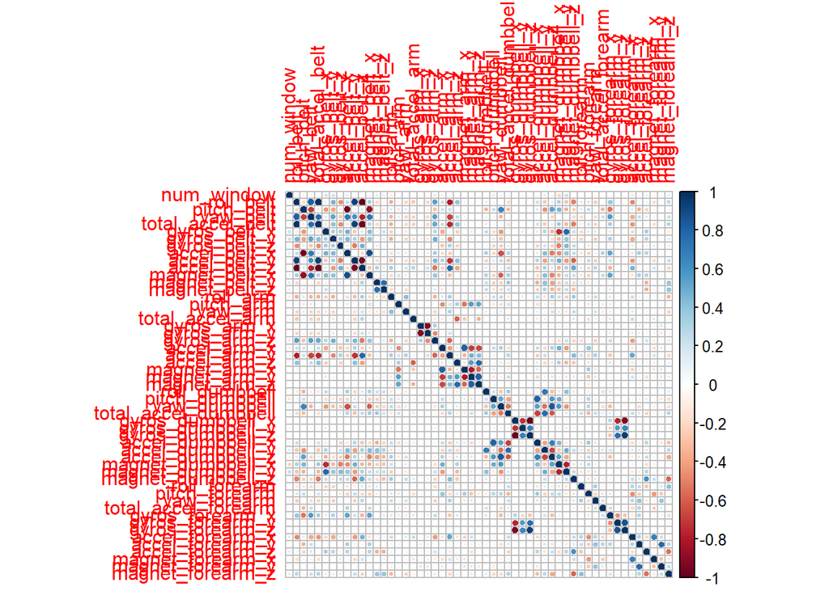

```r
corrplot(cor(training[3:55]))
```